# Google Play Store - Preparando el dataset

En este Notebook vamos a realizar la limpieza del dataset de las Apps pertenecientes a la tienda de Google (Google Play).

El dataset que vamos a analizar fue obtenido mediante Web Scraping por el usuario de Kaggle [Gautham Prakash](https://www.kaggle.com/gauthamp10) .

El dataset fue obtenido en Junio de 2021, y contiene más de 2.3 millones de Apps.

https://www.kaggle.com/gauthamp10/google-playstore-apps

Prakash recolectó el dataset inspirándose en el [famoso dataset de Kaggle de Google Play Store](https://www.kaggle.com/lava18/google-play-store-apps) , y quiso construir un dataset gigante para estudiantes e investigadores.

### Proceso de Data Cleaning

Al igual que hicimos con los datos de Apple, en este notebook limpiaremos a fondo el dataset original, de manera que obtengamos un dataset que se acomode a nuestros propósitos iniciales (que ya establecimos en el Pre-Análisis), para poder realizar un estudio sobre él.

Como en el dataset de Apple, realizaremos tareas de Data Cleaning para obtener un dataset que cumpla lo siguiente:

- Las columnas resultantes sean relevantes para nosotros
- Las Apps disponibles tengan valores que podamos analizar
- Los lenguajes de las Apps sean comparables a los nuestros
- Exista la menor proporción posible de valores nulos
- Todos los datos disponibles sean coherentes con nuestros objetivos

Finalmente, y tal y como hicimos con el dataset de Apple, guardaremos el dataset limpio en un nuevo archivo CSV.

Una vez tengamos ambos CSV limpios, decidiremos si los combinamos entre sí o realizamos los análisis de cada tienda por separado.

## Importaciones y configuración del Notebook

Realizamos las importaciones necesarias y configuramos el Notebook para facilitar las visualizaciones.

```python
import pandas as pd
import seaborn as sns
import matplotlib.pyplot as plt
%matplotlib inline

pd.set_option('display.max_columns', None)

pd.options.mode.chained_assignment = None

from IPython.core.display import HTML
HTML("""
<style>
.output_png {
    display: table-cell;
    text-align: center;
    margin:auto;
}
.prompt
    display:none;
}
}
</style>
""")
```

# 1. Primeras visualizaciones, información, documentación

Vamos a leer nuestro dataset, mostraremos el aspecto del DataFrame resultante y veremos información del mismo:

```python
# Transformamos el dataset en un Pandas DataFrame
google = pd.read_csv("../fat_data/Google-Playstore.csv")
google.head()
```

|  | App Name | App Id | Category | Rating | Rating Count | Installs | Minimum Installs | Maximum Installs | Free | Price | Currency | Size | Minimum Android | Developer Id | Developer Website | Developer Email | Released | Last Updated | Content Rating | Privacy Policy | Ad Supported | In App Purchases | Editors Choice | Scraped Time |
| --- | --- | --- | --- | --- | --- | --- | --- | --- | --- | --- | --- | --- | --- | --- | --- | --- | --- | --- | --- | --- | --- | --- | --- | --- |
| 0 | Gakondo | com.ishakwe.gakondo | Adventure | 0.0 | 0.0 | 10+ | 10.0 | 15 | True | 0.0 | USD | 10M | 7.1 and up | Jean Confident Irénée NIYIZIBYOSE | https://beniyizibyose.tk/#/ | jean21101999@gmail.com | Feb 26, 2020 | Feb 26, 2020 | Everyone | https://beniyizibyose.tk/projects/ | False | False | False | 2021-06-15 20:19:35 |
| 1 | Ampere Battery Info | com.webserveis.batteryinfo | Tools | 4.4 | 64.0 | 5,000+ | 5000.0 | 7662 | True | 0.0 | USD | 2.9M | 5.0 and up | Webserveis | https://webserveis.netlify.app/ | webserveis@gmail.com | May 21, 2020 | May 06, 2021 | Everyone | https://dev4phones.wordpress.com/licencia-de-uso/ | True | False | False | 2021-06-15 20:19:35 |
| 2 | Vibook | com.doantiepvien.crm | Productivity | 0.0 | 0.0 | 50+ | 50.0 | 58 | True | 0.0 | USD | 3.7M | 4.0.3 and up | Cabin Crew | NaN | vnacrewit@gmail.com | Aug 9, 2019 | Aug 19, 2019 | Everyone | https://www.vietnamairlines.com/vn/en/terms-an... | False | False | False | 2021-06-15 20:19:35 |
| 3 | Smart City Trichy Public Service Vehicles 17UC... | cst.stJoseph.ug17ucs548 | Communication | 5.0 | 5.0 | 10+ | 10.0 | 19 | True | 0.0 | USD | 1.8M | 4.0.3 and up | Climate Smart Tech2 | http://www.climatesmarttech.com/ | climatesmarttech2@gmail.com | Sep 10, 2018 | Oct 13, 2018 | Everyone | NaN | True | False | False | 2021-06-15 20:19:35 |
| 4 | GROW.me | com.horodyski.grower | Tools | 0.0 | 0.0 | 100+ | 100.0 | 478 | True | 0.0 | USD | 6.2M | 4.1 and up | Rafal Milek-Horodyski | http://www.horodyski.com.pl | rmilekhorodyski@gmail.com | Feb 21, 2020 | Nov 12, 2018 | Everyone | http://www.horodyski.com.pl | False | False | False | 2021-06-15 20:19:35 |

### Columnas y filas, tamaño del dataset

Vamos a ver los números de nuestros datos

```python
# Columnas del dataset
google.columns
```

```
Index(['App Name', 'App Id', 'Category', 'Rating', 'Rating Count', 'Installs',
       'Minimum Installs', 'Maximum Installs', 'Free', 'Price', 'Currency',
       'Size', 'Minimum Android', 'Developer Id', 'Developer Website',
       'Developer Email', 'Released', 'Last Updated', 'Content Rating',
       'Privacy Policy', 'Ad Supported', 'In App Purchases', 'Editors Choice',
       'Scraped Time'],
      dtype='object')
```

```python
# Número de filas y columnas
google.shape
```

```
(2312944, 24)
```

```python
# Número de datos totales
google.size
```

```
55510656
```

## 1.1. Documentación

Para documentar el dataset, nos vamos al enlace de Kaggle desde el que lo descargamos, y en la sección 'Column' podemos leer una breve descripción de cada columna, las cuales serán nuestra referencia para documentar los datos.

De la misma manera que hicimos con el dataset de Apple, utilizaremos la plantilla para generar la documentación con etiquetas.

```python
for column in google.columns:
    print("- `" + column + "`: ")
```

```
- `App Name`:
- `App Id`:
- `Category`:
- `Rating`:
- `Rating Count`:
- `Installs`:
- `Minimum Installs`:
- `Maximum Installs`:
- `Free`:
- `Price`:
- `Currency`:
- `Size`:
- `Minimum Android`:
- `Developer Id`:
- `Developer Website`:
- `Developer Email`:
- `Released`:
- `Last Updated`:
- `Content Rating`:
- `Privacy Policy`:
- `Ad Supported`:
- `In App Purchases`:
- `Editors Choice`:
- `Scraped Time`:
```

#### DOCUMENTACIÓN DEL DATASET

- `App Name`: nombre de la App
- `App Id`: nombre del paquete. ID
- `Category`: categoría de la App
- `Rating`: valoración media de la App (sobre 5)
- `Rating Count`: número de valoraciones de la App
- `Installs`: número aproximado de instalaciones
- `Minimum Installs`: contador mínimo aproximado de instalaciones
- `Maximum Installs`: contador máximo aproximado de instalaciones
- `Free`: True si es gratis, False si es de pago (son booleanos, no strings)
- `Price`: precio de la App
- `Currency`: moneda en la que se paga la App
- `Size`: tamaño de la App
- `Minimum Android`: mínima versión de Android requerida por la App
- `Developer Id`: ID del desarrollador de la App en Google Play Store
- `Developer Website`: sitio web del desarrollador
- `Developer Email`: ID del e-mail del desarrollador
- `Released`: fecha de lanzamiento de la App en Google Play Store
- `Last Updated`: fecha de la última actualización recibida
- `Content Rating`: edad mínima requerida para utilizar la App
- `Privacy Policy`: política de privacidad según el desarrollador
- `Ad Supported`: publicidad en la App (True o False)
- `In App Purchases`: compras disponibles en la App (True o False)
- `Editors Choice`: clasificado como elección del editor
- `Scraped Time`: fecha de obtención del dato (scraping)

# 2. Data Cleaning

A partir de aquí empezaremos a limpiar el dataset.

Echando un vistazo a la documentación del mismo, ya podemos descartar muchos datos que no nos van a servir. Podemos eliminar buena parte de los datos, para empezar a trabajar con un volumen de datos menor y hacer más eficiente el trabajo.

Unos cuantos ejemplos de datos que podemos eliminar serían los siguientes:

- Muchas columnas no las vamos a necesitar:
  - `App Id`
  - `Minimum Android`
  - `Developer Website`
  - `Developer Email`
  - `Privacy Policy`
  - `Editors Choice`
  - `Scraped Time`
- La columna `Developer Id` la mantendremos porque, si echamos un vistazo al DataFrame, podremos observar que en realidad el ID es el nombre del desarrollador, y este dato podría aportarnos valor en los análisis futuros (por ejemplo, para agrupar por desarrolladores).
- La columna `Free`nos indica si la App es de pago o no. Como no nos interesan las Apps de pago, podemos descartar todas las que no sean gratuitas.
- La columna `Ad Supported` nos indica si la App dispone de soporte para publicidad o no. Podemos descartar todas las que no tengan soporte para publicidad (nosotros sí lo tendremos).

Respecto a la última columna que hemos mencionado `Ad Supported` , si echamos un vistazo a la sección 'Column' del link del dataset en Kaggle, podemos observar que aproximadamente el 50% de las Apps del dataset no tienen soporte para publicidad, por lo que sería bueno empezar por aquí para eliminar gran cantidad de datos de una sola vez. Después de esto, eliminaremos las columnas que acabamos de mencionar.

## 2.1. Soporte para publicidad

Como hemos dicho, vamos a ver las Apps que no soportan anuncios. Trataremos de profundizar un poco en los datos para averiguar por qué no soportan publicidad, si es que podemos sacar algo en claro.

```python
# Apps que no soportan publicidad
no_publi = google[google['Ad Supported'] == False]
no_publi
```

|  | App Name | App Id | Category | Rating | Rating Count | Installs | Minimum Installs | Maximum Installs | Free | Price | Currency | Size | Minimum Android | Developer Id | Developer Website | Developer Email | Released | Last Updated | Content Rating | Privacy Policy | Ad Supported | In App Purchases | Editors Choice | Scraped Time |
| --- | --- | --- | --- | --- | --- | --- | --- | --- | --- | --- | --- | --- | --- | --- | --- | --- | --- | --- | --- | --- | --- | --- | --- | --- |
| 0 | Gakondo | com.ishakwe.gakondo | Adventure | 0.0 | 0.0 | 10+ | 10.0 | 15 | True | 0.0 | USD | 10M | 7.1 and up | Jean Confident Irénée NIYIZIBYOSE | https://beniyizibyose.tk/#/ | jean21101999@gmail.com | Feb 26, 2020 | Feb 26, 2020 | Everyone | https://beniyizibyose.tk/projects/ | False | False | False | 2021-06-15 20:19:35 |
| 2 | Vibook | com.doantiepvien.crm | Productivity | 0.0 | 0.0 | 50+ | 50.0 | 58 | True | 0.0 | USD | 3.7M | 4.0.3 and up | Cabin Crew | NaN | vnacrewit@gmail.com | Aug 9, 2019 | Aug 19, 2019 | Everyone | https://www.vietnamairlines.com/vn/en/terms-an... | False | False | False | 2021-06-15 20:19:35 |
| 4 | GROW.me | com.horodyski.grower | Tools | 0.0 | 0.0 | 100+ | 100.0 | 478 | True | 0.0 | USD | 6.2M | 4.1 and up | Rafal Milek-Horodyski | http://www.horodyski.com.pl | rmilekhorodyski@gmail.com | Feb 21, 2020 | Nov 12, 2018 | Everyone | http://www.horodyski.com.pl | False | False | False | 2021-06-15 20:19:35 |
| 5 | IMOCCI | com.imocci | Social | 0.0 | 0.0 | 50+ | 50.0 | 89 | True | 0.0 | USD | 46M | 6.0 and up | Imocci GmbH | http://www.imocci.com | info@imocci.com | Dec 24, 2018 | Dec 20, 2019 | Teen | https://www.imocci.com/wp-content/uploads/2018... | False | True | False | 2021-06-15 20:19:35 |
| 7 | The Everyday Calendar | com.mozaix.simoneboard | Lifestyle | 2.0 | 39.0 | 500+ | 500.0 | 702 | True | 0.0 | USD | 16M | 5.0 and up | Mozaix LLC | NaN | elementuser03@gmail.com | Jun 21, 2019 | Jun 21, 2019 | Everyone | https://www.freeprivacypolicy.com/privacy/view... | False | False | False | 2021-06-15 20:19:35 |
| ... | ... | ... | ... | ... | ... | ... | ... | ... | ... | ... | ... | ... | ... | ... | ... | ... | ... | ... | ... | ... | ... | ... | ... | ... |
| 2312936 | Engineers Careers | com.eventapps.eventapps | Business | 0.0 | 0.0 | 100+ | 100.0 | 353 | True | 0.0 | USD | 21M | 5.0 and up | Eventi | NaN | rami.osama.selim@gmail.com | Mar 5, 2020 | Feb 29, 2020 | Everyone | NaN | False | False | False | 2021-06-16 12:59:18 |
| 2312937 | STMIK Mercusuar - Aditya Rachman | com.aplikasi.datapribadiadit | Education | 0.0 | 0.0 | 5+ | 5.0 | 7 | True | 0.0 | USD | 6.6M | 4.4 and up | STMIK Mercusuar | NaN | rachmanaditya5@gmail.com | Jan 15, 2020 | Jan 15, 2020 | Everyone | NaN | False | False | False | 2021-06-16 12:59:18 |
| 2312939 | 大俠客—熱血歸來 | com.rxsj.ssjj | Role Playing | 4.3 | 16775.0 | 100,000+ | 100000.0 | 337109 | True | 0.0 | USD | 77M | 4.1 and up | ALICE GAME | http://www.4399sy.com.hk/ | ssjjcomhk@gmail.com | NaN | Jun 01, 2021 | Teen | http://a.4399sy.com.hk/user/aggreement | False | False | False | 2021-06-16 12:59:18 |
| 2312940 | ORU Online | com.threedream.oruonline | Education | 0.0 | 0.0 | 100+ | 100.0 | 430 | True | 0.0 | USD | 44M | 4.1 and up | 3Dream Studios, LLC | http://www.oru.edu/ | 3DreamDeveloper@gmail.com | Jan 17, 2018 | Feb 02, 2018 | Everyone | http://www.oru.edu/about-oru/privacy-policy.php | False | False | False | 2021-06-16 12:59:19 |
| 2312941 | Data Structure | datastructure.appoworld.datastucture | Education | 0.0 | 0.0 | 100+ | 100.0 | 202 | True | 0.0 | USD | 29M | 5.0 and up | appoworld | NaN | appoworld.official@gmail.com | Aug 19, 2018 | Aug 19, 2018 | Everyone | https://appoworld.000webhostapp.com/datastruct... | False | False | False | 2021-06-16 12:59:19 |

1162170 rows × 24 columns

Como hemos dicho, prácticamente la mitad de Apps presentes en el DataFrame no soportan publicidad. Vamos a estudiar las causas.

Primeramente, vamos a ver cuantas de ellas son de pago o tienen algún tipo de contenido de pago, ya que tendría sentido que una App que no es gratuita no incluya publicidad.

```python
no_publi[(no_publi['In App Purchases'] == True) | (no_publi['Free'] == False)]
```

|  | App Name | App Id | Category | Rating | Rating Count | Installs | Minimum Installs | Maximum Installs | Free | Price | Currency | Size | Minimum Android | Developer Id | Developer Website | Developer Email | Released | Last Updated | Content Rating | Privacy Policy | Ad Supported | In App Purchases | Editors Choice | Scraped Time |
| --- | --- | --- | --- | --- | --- | --- | --- | --- | --- | --- | --- | --- | --- | --- | --- | --- | --- | --- | --- | --- | --- | --- | --- | --- |
| 5 | IMOCCI | com.imocci | Social | 0.0 | 0.0 | 50+ | 50.0 | 89 | True | 0.00 | USD | 46M | 6.0 and up | Imocci GmbH | http://www.imocci.com | info@imocci.com | Dec 24, 2018 | Dec 20, 2019 | Teen | https://www.imocci.com/wp-content/uploads/2018... | False | True | False | 2021-06-15 20:19:35 |
| 60 | PowerSwitch | eu.power_switch | Lifestyle | 4.3 | 266.0 | 10,000+ | 10000.0 | 43836 | True | 0.00 | USD | 7.1M | 4.0 and up | Markus Ressel | http://power-switch.eu | contact@power-switch.eu | Oct 24, 2015 | Apr 16, 2016 | Everyone | https://github.com/Power-Switch/PowerSwitch_An... | False | True | False | 2021-06-15 20:19:39 |
| 208 | ZEIT AUDIO | de.zeit.audio | News & Magazines | 4.6 | 1831.0 | 50,000+ | 50000.0 | 59566 | True | 0.00 | USD | 13M | 5.0 and up | ZEIT ONLINE | http://www.zeit.de | apps@zeit.de | Apr 16, 2014 | Feb 01, 2021 | Everyone | http://www.zeit.de/hilfe/datenschutz | False | True | False | 2021-06-15 20:19:48 |
| 273 | Limitless Paint | com.bytescaffold.limitlesspaint | Tools | 4.5 | 236.0 | 10,000+ | 10000.0 | 34125 | False | 1.99 | USD | 1.6M | 4.1 and up | Bitscaffold | NaN | traista.rafael@yahoo.com | Nov 30, 2018 | Apr 08, 2019 | Everyone | http://htmlpreview.github.io/?https://github.c... | False | False | False | 2021-06-15 20:19:52 |
| 296 | Standalone Golf GPS by Hole19 | com.hole19golf.wear | Sports | 2.8 | 160.0 | 10,000+ | 10000.0 | 10407 | False | 4.99 | USD | 30M | 7.1 and up | Hole19 | https://www.hole19golf.com | help@hole19golf.com | Feb 7, 2017 | Dec 22, 2020 | Everyone | https://www.hole19golf.com/terms/#PrivacyPolicy | False | False | False | 2021-06-15 20:19:53 |
| ... | ... | ... | ... | ... | ... | ... | ... | ... | ... | ... | ... | ... | ... | ... | ... | ... | ... | ... | ... | ... | ... | ... | ... | ... |
| 2312803 | New Cute Kitty Cats & Animals LOVE. WAStickerApps | com.wastickerapps.wasticker.sticker.emoji.new.... | Entertainment | 0.0 | 0.0 | 1+ | 1.0 | 3 | False | 0.99 | USD | 5.1M | 4.0.3 and up | WAStickerApps WAStickers | https://sites.google.com/view/wastickerapps-wa... | wastickerappsstickers@gmail.com | Feb 6, 2019 | Feb 06, 2019 | Everyone | https://sites.google.com/view/wastickerapps-wa... | False | False | False | 2021-06-16 12:59:11 |
| 2312819 | WISO Steuer – Steuererklärung einfach gemacht. | de.buhl.steuerphone | Finance | 4.7 | 4055.0 | 100,000+ | 100000.0 | 310410 | True | 0.00 | USD | 15M | 6.0 and up | Buhl Data Service GmbH | https://www.steuer-web.de | support@wiso-steuer.de | Jun 30, 2020 | Jun 07, 2021 | Everyone | https://www.buhl.de/steuer-web/datenschutz/ | False | True | False | 2021-06-16 12:59:12 |
| 2312827 | Polski Traker | com.publuu.p421 | News & Magazines | 0.0 | 0.0 | 100+ | 100.0 | 103 | True | 0.00 | USD | 19M | 5.0 and up | PUBLUU | http://www.polskitraker.pl/ | info@publuu.com | Mar 25, 2020 | Mar 25, 2020 | Everyone | https://polskitraker.publuu.com/newsstand/privacy | False | True | False | 2021-06-16 12:59:13 |
| 2312879 | Diabetic Living Australia | au.com.pacificmags.digital.diabeticliving | News & Magazines | 3.4 | 5.0 | 1,000+ | 1000.0 | 1479 | True | 0.00 | USD | 34M | 5.0 and up | Are Media Pty Limited | http://www.aremedia.com.au | digitalmags@magshop.com.au | Dec 10, 2014 | Oct 26, 2020 | Everyone | http://pacificmagazines.com.au/Info/informatio... | False | True | False | 2021-06-16 12:59:15 |
| 2312927 | Gear Ratio Calculator | jp.abt.lopnur.gearratiocalc | Sports | 0.0 | 0.0 | 100+ | 100.0 | 201 | False | 2.49 | USD | 994k | 2.1 and up | ABT | http://www.abt.jp | abtdev@gmail.com | Jun 19, 2012 | Nov 09, 2012 | Everyone | NaN | False | False | False | 2021-06-16 12:59:18 |

93621 rows × 24 columns

Solamente 93,621 Apps cumplen alguno de los dos requisitos que hemos establecido, de un total de 1,162,170 Apps (ni siquiera un 10%).

**Vamos a plantear una teoría, que veremos si es cierta o no apoyándonos en nuestros datos:**

Podríamos pensar que muchas Apps pueden ser de desarrolladores *indie* , de estudiantes, etc., que simplemente han desarrollado una App básica y ni siquiera tienen intención de lucrarse con ella, han almacenado su App en la Play Store para ver cuantos usuarios se la descargan, o para realizar algún tipo de testeo, y por tanto, ni siquiera han implementado la posibilidad de incluir publicidad en la App. Esto tendría sentido.

Para comprobar esta hipótesis, vamos a ver el número de instalaciones medias de las Apps que no soportan publicidad Vs. el número de instalaciones medias de las Apps que sí soportan. Si nuestra teoría fuese cierta, la diferencia debería ser, por lo menos, significativa.

Antes de calcular las medias, debemos convertir los strings —así vienen por defecto las instalaciones— en tipo numérico para poder operar con ellos.

```python
# Tabla de frecuencias de la columna 'Installs'
google['Installs'].value_counts()
```

```
100+               443368
1,000+             398199
10+                300156
10,000+            256723
500+               189077
50+                170465
5,000+             143593
100,000+           110257
50,000+             75359
5+                  73772
1+                  65345
1,000,000+          33650
500,000+            27012
0+                  11566
5,000,000+           6595
10,000,000+          6192
50,000,000+           824
100,000,000+          549
500,000,000+           65
1,000,000,000+         55
5,000,000,000+         14
10,000,000,000+         1
Name: Installs, dtype: int64
```

```python
# Eliminamos los símbolos '+' que están al final de cada string
google['Installs'] = google['Installs'].str[:-1]
google['Installs']
```

```
0               10
1            5,000
2               50
3               10
4              100
            ...
2312939    100,000
2312940        100
2312941        100
2312942      1,000
2312943        100
Name: Installs, Length: 2312944, dtype: object
```

```python
# Ahora eliminamos las comas presentes en los strings para poder transformarlos en numéricos
google.Installs = google.Installs.str.replace(',', '')
google.Installs
```

```
0              10
1            5000
2              50
3              10
4             100
            ...
2312939    100000
2312940       100
2312941       100
2312942      1000
2312943       100
Name: Installs, Length: 2312944, dtype: object
```

```python
# Convertimos ahora los datos a numérico
google.Installs = pd.to_numeric(google.Installs)
google.Installs
```

```
0              10.0
1            5000.0
2              50.0
3              10.0
4             100.0
             ...
2312939    100000.0
2312940       100.0
2312941       100.0
2312942      1000.0
2312943       100.0
Name: Installs, Length: 2312944, dtype: float64
```

Ahora que tenemos los datos numéricos, calculamos la media de instalaciones para las Apps que soportan publicidad y para las que no lo soportan:

```python
# Media de instalaciones: Apps gratuitas que soportan publicidad
google[(google['Ad Supported'] == True) & (google['Free'] == True)]['Installs'].mean()
```

```
218060.71473228635
```

```python
# Media de instalaciones: Apps gratuitas que no soportan publicidad
google[(google['Ad Supported'] == False) & (google['Free'] == True)]['Installs'].mean()
```

```
154955.06925560275
```

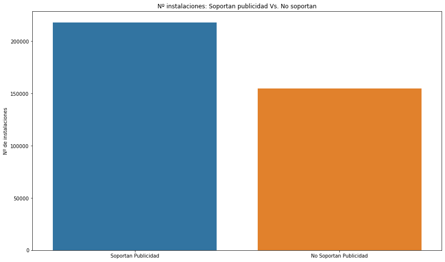

```python
plt.figure(figsize=(15,9))
plt.title('Nº instalaciones: Soportan publicidad Vs. No soportan')
plt.ylabel('Nº de instalaciones')
sns.barplot(x=['Soportan Publicidad', 'No Soportan Publicidad'], y=[218060, 154955]);
```

Las Apps que soportan publicidad tuvieron un 40% más de instalaciones (de media). Estos números incluso pueden estar inflados por Apps como WhatsApp, Google Drive, etc. que tienen una cantidad enorme de instalaciones y no permiten publicidad.

Las siguientes Apps tienen más de 1000 Millones de instalaciones:

```python
google[google['Installs'] > 1000000000][['App Name', 'Installs', 'Ad Supported']]
```

|  | App Name | Installs | Ad Supported |
| --- | --- | --- | --- |
| 167781 | Google TV (previously Play Movies & TV) | 5.000000e+09 | False |
| 385470 | WhatsApp Messenger | 5.000000e+09 | False |
| 881403 | YouTube | 5.000000e+09 | True |
| 893676 | Google Drive | 5.000000e+09 | False |
| 925338 | Hangouts | 5.000000e+09 | False |
| 944254 | Google Chrome: Fast & Secure | 5.000000e+09 | False |
| 1060335 | Google Text-to-Speech | 5.000000e+09 | False |
| 1733042 | Google Maps - Navigate & Explore | 5.000000e+09 | True |
| 1773294 | Google | 5.000000e+09 | True |
| 1830962 | Google Photos | 5.000000e+09 | False |
| 2011395 | Android Accessibility Suite | 5.000000e+09 | False |
| 2095852 | Messenger – Text and Video Chat for Free | 5.000000e+09 | False |
| 2099458 | Gmail | 5.000000e+09 | True |
| 2155096 | Google Play services | 1.000000e+10 | False |
| 2222701 | Facebook | 5.000000e+09 | True |

Vemos que todas excepto una tienen más de 5000 Millones. Parece que la mayoría de ellas no admiten publicidad:

```python
google[google['Installs'] > 1000000000]['Ad Supported'].value_counts()
```

```
False    10
True      5
Name: Ad Supported, dtype: int64
```

Si volvemos a filtrar, obtendremos unos datos distintos:

```python
# 1. Creamos una lista de las Apps con más instalaciones (ahora filtraremos en ella)
apps_mas_instalaciones = [app for app in google[google['Installs'] > 1000000000]['App Name']]
apps_mas_instalaciones
```

```
['Google TV (previously Play Movies & TV)',
 'WhatsApp Messenger',
 'YouTube',
 'Google Drive',
 'Hangouts',
 'Google Chrome: Fast & Secure',
 'Google Text-to-Speech',
 'Google Maps - Navigate & Explore',
 'Google',
 'Google Photos',
 'Android Accessibility Suite',
 'Messenger – Text and Video Chat for Free',
 'Gmail',
 'Google Play services',
 'Facebook']
```

```python
# 2. Filtramos en la lista. Apps que soportan publicidad: media de instalaciones
google[(google['Ad Supported'] == True) & (google['Free'] == True) & ~(google['App Name']).isin(apps_mas_instalaciones)]['Installs'].mean()
```

```
196286.6714850371
```

```python
# 3. Filtramos en la lista. Apps que no soportan publicidad: media de instalaciones
google[(google['Ad Supported'] == False) & (google['Free'] == True) & ~(google['App Name']).isin(apps_mas_instalaciones)]['Installs'].mean()
```

```
105838.65574492255
```

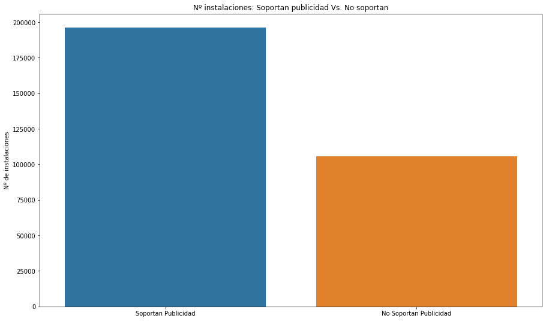

```python
plt.figure(figsize=(15,9))
plt.title('Nº instalaciones: Soportan publicidad Vs. No soportan')
plt.ylabel('Nº de instalaciones')
sns.barplot(x=['Soportan Publicidad', 'No Soportan Publicidad'], y=[196286, 105838]);
```

En este caso vemos que las Apps que soportan publicidad tienen aproximadamente el doble de instalaciones medias que las que no soportan publicidad.

Toda esta explicación ha sido un poco tediosa, pero de alguna forma ha demostrado que nuestra hipótesis era cierta, y que muchas de las Apps gratuitas contenidas en el dataset que no soportan publicidad, no son en realidad productos, sino testeos, Apps de prueba, etc.

Si profundizásemos más en los datos podríamos acercarnos más a demostrar totalmente esta teoría; la diferencia en el número de instalaciones sería cada vez más pronunciada, ya que simplemente eliminando las Apps con mayor número de instalaciones hemos visto como la diferencia en el número de instalaciones medias es del 100%, por lo que damos como validada la teoría.

Por tanto, podemos eliminar todas las Apps presentes en el DataFrame que no soportan publicidad, ya que concluimos que no son Apps que sean productos como tal (mientras que nuestra App sí soportará publicidad y sí tenemos intención de obtener rentabilidad de ella).

```python
# Solo mantenemos las Apps que soportan publicidad. Mostramos la cantidad de Apps restantes
google = google[google['Ad Supported'] == True]
google.shape
```

```
(1150774, 24)
```

## 2.2. Columnas innecesarias

Vamos a seguir eliminando grandes cantidades de datos que no necesitamos para nuestro análisis.

Ya hicimos una lista de columnas que son prescindibles para nosotros:

- `App Id`
- `Minimun Android`
- `Developer Website`
- `Developer Email`
- `Privacy Policy`
- `Editors Choice`
- `Scraped Time`

Vamos a eliminarlas directamente, y veremos cuantos datos totales hemos eliminado.

```python
# Datos totales del DataFrame en este momento
google.size
```

```
27618576
```

```python
# Eliminamos las columnas
cols_eliminar = ['App Id', 'Minimum Android', 'Developer Website', 'Developer Email',
                'Privacy Policy', 'Editors Choice', 'Scraped Time']
google = google.drop(columns=cols_eliminar)
google.columns
```

```
Index(['App Name', 'Category', 'Rating', 'Rating Count', 'Installs',
       'Minimum Installs', 'Maximum Installs', 'Free', 'Price', 'Currency',
       'Size', 'Developer Id', 'Released', 'Last Updated', 'Content Rating',
       'Ad Supported', 'In App Purchases'],
      dtype='object')
```

```python
# Tamaño actual del DataFrame
google.size
```

```
19563158
```

Simplemente eliminando columnas innecesarias hemos eliminado más de 8,000,000 de datos, lo que aligera bastante nuestro DataFrame.

## 2.3. Estandarización de columnas

Una buena práctica es estandarizar todas las columnas del DataFrame. En nuestro caso, reemplazaremos los espacios por barras bajas y todas las letras serán minúsculas.

También vamos a renombrar la columna `Content Rating` a un nombre más intuitivo, como `age`, ya que esta columna representa la edad requerida para utilizar la App.

```python
# Estandarizamos las columnas en base a nuestros criterios
google.columns = google.columns.str.lower().str.replace(' ', '_')
google.columns
```

```
Index(['app_name', 'category', 'rating', 'rating_count', 'installs',
       'minimum_installs', 'maximum_installs', 'free', 'price', 'currency',
       'size', 'developer_id', 'released', 'last_updated', 'content_rating',
       'ad_supported', 'in_app_purchases'],
      dtype='object')
```

```python
# Renombramos la columna 'content_rating'
google = google.rename(columns={'content_rating': 'age'})
google.columns
```

```
Index(['app_name', 'category', 'rating', 'rating_count', 'installs',
       'minimum_installs', 'maximum_installs', 'free', 'price', 'currency',
       'size', 'developer_id', 'released', 'last_updated', 'age',
       'ad_supported', 'in_app_purchases'],
      dtype='object')
```

## 2.4. Apps gratuitas

Vamos a seguir eliminando la mayor cantidad de datos posible de una manera sencilla. En este caso, vamos a eliminar todas las Apps de pago presentes en el DataFrame, ya que no nos interesa estudiar el mercado de Apps de pago, y eliminaremos una buena cantidad de datos de una forma muy rápida.

Vamos a ver cuantas Apps de pago tenemos en el DataFrame y las vamos a eliminar:

```python
# Número de Apps de pago
google[google['free'] == False].size
```

```
45271
```

```python
# Mantenemos únicamente las Apps gratuitas
google = google[google['free'] == True]
google.shape
```

```
(1148111, 17)
```

Con estos pasos tan sencillos que hemos dado hasta ahora, hemos eliminado algo más del 50% de Apps del dataset.

En cuanto a datos brutos totales, teníamos al principio 55,510,656 datos.

```python
# Total de datos brutos actuales
google.size
```

```
19517887
```

Ahora mismo tenemos algo menos de 20 millones de datos, por lo que hemos eliminado más del 60% de datos totales, entre columnas que no necesitábamos y filas que no nos interesan.

Vamos a seguir eliminando datos. Esta vez, vamos a ver cuantas Apps gratuitas ofrecen contenido adicional de pago.

### 2.4.1. Apps gratuitas con contenido de pago

Vamos a comprobar si existen Apps que, siendo gratuitas, ofrecen contenido de pago adicional. Este dato nos lo ofrece la columna `in_app_purchases` :

```python
# DataFrame que contiene todas las Apps que ofrecen contenido adicional de pago
google[google['in_app_purchases'] == True]
```

|  | app_name | category | rating | rating_count | installs | minimum_installs | maximum_installs | free | price | currency | size | developer_id | released | last_updated | age | ad_supported | in_app_purchases |
| --- | --- | --- | --- | --- | --- | --- | --- | --- | --- | --- | --- | --- | --- | --- | --- | --- | --- |
| 22 | Block Fill: Puzzle Game | Puzzle | 4.4 | 211.0 | 10000.0 | 10000.0 | 15471 | True | 0.0 | USD | 16M | MailBee Games | Mar 13, 2020 | May 11, 2020 | Everyone | True | True |
| 25 | Sticky Ball | Arcade | 4.6 | 11.0 | 100.0 | 100.0 | 152 | True | 0.0 | USD | 25M | Mitochondria Studios | Mar 5, 2018 | Mar 26, 2018 | Everyone | True | True |
| 26 | CUBIC RUNNER | Arcade | 0.0 | 0.0 | 1000.0 | 1000.0 | 1068 | True | 0.0 | USD | 16M | GA software | Apr 1, 2015 | Apr 16, 2015 | Everyone | True | True |
| 43 | Extrude Balance | Arcade | 5.0 | 8.0 | 1000.0 | 1000.0 | 3427 | True | 0.0 | USD | 26M | Creators Bureau | Jul 8, 2019 | May 01, 2021 | Everyone | True | True |
| 49 | Bowling Paradise Pro FREE | Sports | 4.4 | 2781.0 | 100000.0 | 100000.0 | 340980 | True | 0.0 | USD | 38M | InnoLab | Apr 27, 2013 | Mar 21, 2015 | Everyone | True | True |
| ... | ... | ... | ... | ... | ... | ... | ... | ... | ... | ... | ... | ... | ... | ... | ... | ... | ... |
| 2312861 | Online Aura Photography | Health & Fitness | 1.8 | 172.0 | 10000.0 | 10000.0 | 39476 | True | 0.0 | USD | 61M | Parthesh Dhaggal | Mar 20, 2018 | Jan 12, 2019 | Everyone | True | True |
| 2312867 | CoupleFace | Social | 0.0 | 0.0 | 100.0 | 100.0 | 312 | True | 0.0 | USD | 9.1M | AburaGame Inc. | Jan 24, 2016 | Dec 06, 2016 | Teen | True | True |
| 2312888 | New Land Quest | Adventure | 0.0 | 0.0 | 10.0 | 10.0 | 24 | True | 0.0 | USD | 73M | Green117 | May 3, 2020 | May 04, 2020 | Everyone | True | True |
| 2312892 | SIF VPN 2019 \| Phone Booster | Tools | 0.0 | 0.0 | 100.0 | 100.0 | 128 | True | 0.0 | USD | 14M | Sabahat Zafar | Jul 24, 2019 | Jul 24, 2019 | Everyone | True | True |
| 2312932 | Hopeless 2: Cave Escape | Action | 4.3 | 103466.0 | 5000000.0 | 5000000.0 | 7274660 | True | 0.0 | USD | 37M | Upopa Games | Oct 29, 2015 | Mar 06, 2017 | Teen | True | True |

141058 rows × 17 columns

Tenemos 141,058 Apps, que vamos a eliminar directamente, porque no son parte del mercado al que nos queremos incorporar.

```python
# Eliminamos dichas Apps, y mostramos las resultantes
google = google[google['in_app_purchases'] == False]
google.shape
```

```
(1007053, 17)
```

Ahora mismo tenemos poco más de 1,000,000 de Apps disponibles. Vamos a estudiar los valores nulos del DataFrame.

## 2.5. Valores nulos

La función *info* es muy útil para hacernos una idea general de los valores nulos presentes en el DataFrame:

```python
# Valores nulos por columnas
google.info()
```

```
<class 'pandas.core.frame.DataFrame'>
Int64Index: 1007053 entries, 1 to 2312943
Data columns (total 17 columns):
 #   Column            Non-Null Count    Dtype
---  ------            --------------    -----
 0   app_name          1007051 non-null  object
 1   category          1007053 non-null  object
 2   rating            1001911 non-null  float64
 3   rating_count      1001911 non-null  float64
 4   installs          1007053 non-null  float64
 5   minimum_installs  1007053 non-null  float64
 6   maximum_installs  1007053 non-null  int64
 7   free              1007053 non-null  bool
 8   price             1007053 non-null  float64
 9   currency          1007053 non-null  object
 10  size              1007002 non-null  object
 11  developer_id      1007045 non-null  object
 12  released          993831 non-null   object
 13  last_updated      1007053 non-null  object
 14  age               1007053 non-null  object
 15  ad_supported      1007053 non-null  bool
 16  in_app_purchases  1007053 non-null  bool
dtypes: bool(3), float64(5), int64(1), object(8)
memory usage: 118.1+ MB
```

Nuestro DataFrame, en general, no tiene una gran cantidad de valores nulos en relación a su tamaño.

Vamos a aprovechar la función que creamos para generar un mapa de calor de valores nulos durante el proceso de Data Cleaning del dataset de Apple:

```python
# Función para crear una null matrix
def matriz_nulos(df, figsize=(18,15)):
    """Recibe un DataFrame y un tamaño, y muestra un mapa de calor
    con la distribución de valores nulos del DataFrame.

    Params:
        df: Pandas DataFrame
        figsize: tamaño del mapa de calor resultante

    Returns:
        Se evita el return por motivos estéticos.
        En este caso simplemente se muestra el mapa de calor resultante.
    """
    # Creamos una figura con el tamaño deseado
    # (por defecto las dimensiones son adecuadas para un notebook de Anaconda)
    plt.figure(figsize=figsize)
    # Creamos un DataFrame booleano de valores nulos
    df_null = df.isnull()
    # Creamos un mapa de calor para el DataFrame booleano
    sns.heatmap(~df_null, cbar=False, yticklabels=False)
    plt.xticks(rotation=90, size='x-large')
    plt.show()
```

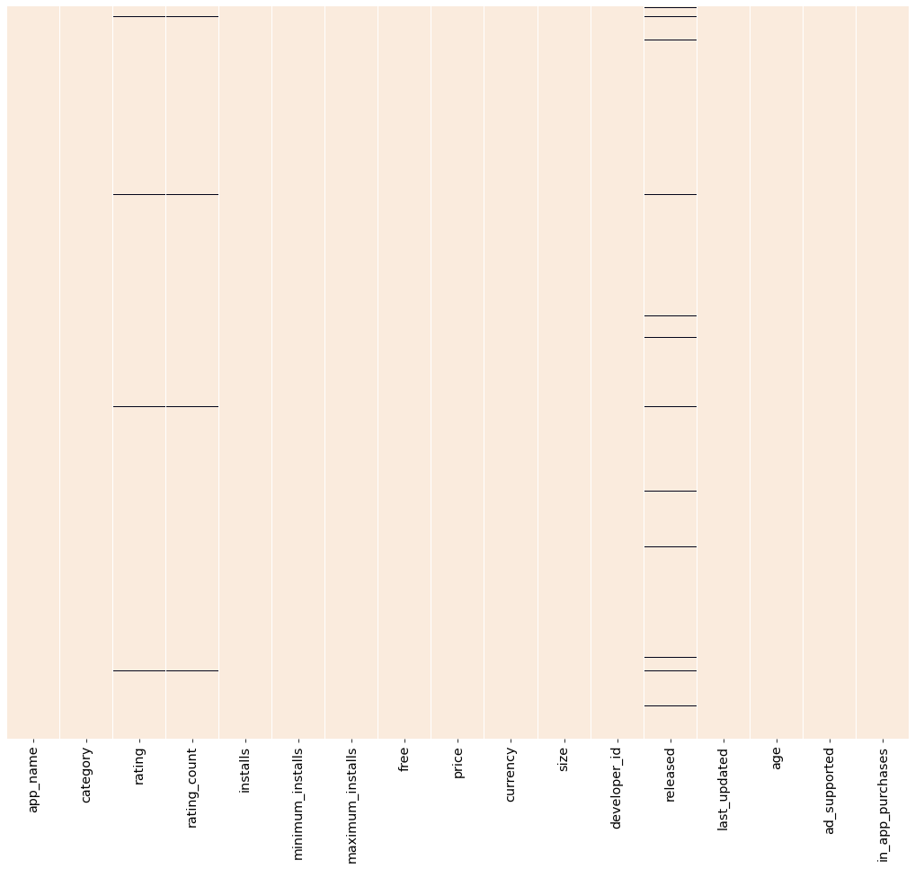

```python
# Mostramos el mapa de calor de valores nulos para nuestro DataFrame
matriz_nulos(google)
```

Como vemos, tenemos un DataFrame —en líneas generales— muy limpio y en general libre de valores nulos.

Las líneas negras indican los valores nulos, mientras que el color beige indica que existen valores. Por supuesto, esto no quiere decir que estos valores (que existen) tengan sentido; eso lo iremos estudiando durante el proceso de limpieza.

De momento, lo que podemos observar en el mapa es que los (pocos) valores nulos que tenemos se concentran únicamente en tres columnas:

- `rating`
- `rating_count`
- `released`

Las columnas `rating` y `rating_count` son representativas de datos necesarios para nuestros análisis, pero en principio, al existir también variables como el número de instalaciones, llegado el caso, podríamos estudiar éstas últimas.

La columna `released` puede ofrecernos información sobre qué tal envejecen las Apps en la Play Store, pero tampoco es un dato definitivo que nos vaya a echar por tierra los análisis que realicemos en el futuro. Además, también podemos adivinar si una App es rentable para una empresa si dicha App se actualiza regularmente. Si tenemos una lista de Apps de las que desconocemos su fecha de lanzamiento, pero todas ellas recibieron actualizaciones hace poco, podemos determinar que las Apps están generando beneficios.

Aún así, como todavía tenemos que realizar muchos filtros antes de obtener nuestro dataset definitivo (sobre el que realizaremos el estudio), vamos a confiar en que algunos de los valores nulos irán desapareciendo a medida que sigamos limpiando el DataFrame.

## 2.6. Lenguajes - caracteres indeseados

Tal y como hicimos con el dataset de Apple, queremos filtrar las Apps que estén enfocadas en los mercados occidentales.

En este dataset no tenemos ningún dato que directamente nos indique los idiomas disponibles de cada App. Sin embargo, podemos utilizar herramientas que nos permitan detectar si una App tiene caracteres no-occidentales en su nombre.

Utilizaremos la misma metodología que utilizamos en el proceso de limpieza del dataset de Apple, ya que pudimos comprobar que fue bastante eficaz.

Vamos a explicar brevemente el procedimiento:

- Iteraremos sobre todos los nombres de las Apps que tenemos
- Iteraremos sobre cada uno de los caracteres de los nombres
- Si el caracter no es ASCII, 'ñ' o '™', eliminaremos dicha App

La función de Python que nos permite comprobar el número asociado a cada caracter es la función *ord*, que recibe un caracter y devuelve su número Unicode.

Si el número Unicode es mayor a 127 o distinto de los números asociados a los caracteres que nos interesan, sabremos que esta App contiene caracteres extraños.

Podríamos profundizar más en este filtrado y afinarlo mejor, pero también es cierto que de esta manera nos aseguramos de eliminar muchas Apps indeseadas, y que el impacto que tendría realizar un análisis más exhaustivo tampoco sería tan grande como para perder más tiempo en ello.

Por tanto, vamos a realizar directamente las operaciones.

```python
# Vamos a resetear los índices del DataFrame
google = google.reset_index(drop=True)
google.head(3)
```

|  | app_name | category | rating | rating_count | installs | minimum_installs | maximum_installs | free | price | currency | size | developer_id | released | last_updated | age | ad_supported | in_app_purchases |
| --- | --- | --- | --- | --- | --- | --- | --- | --- | --- | --- | --- | --- | --- | --- | --- | --- | --- |
| 0 | Ampere Battery Info | Tools | 4.4 | 64.0 | 5000.0 | 5000.0 | 7662 | True | 0.0 | USD | 2.9M | Webserveis | May 21, 2020 | May 06, 2021 | Everyone | True | False |
| 1 | Smart City Trichy Public Service Vehicles 17UC... | Communication | 5.0 | 5.0 | 10.0 | 10.0 | 19 | True | 0.0 | USD | 1.8M | Climate Smart Tech2 | Sep 10, 2018 | Oct 13, 2018 | Everyone | True | False |
| 2 | unlimited 4G data prank free app | Libraries & Demo | 4.5 | 12.0 | 1000.0 | 1000.0 | 2567 | True | 0.0 | USD | 2.5M | android developer779 | Sep 23, 2019 | Sep 27, 2019 | Everyone | True | False |

Existen algunos nombres de Apps que no son de tipo string, sino que (por algún motivo extraño, quizás en el proceso de Web Scraping) son de tipo numérico.

Vamos a asegurarnos primero de que todos los nombres de las Apps son de tipo string para poder iterarlos:

```python
# Con 'astype' convertimos todos los valores a string
google['app_name'] = google['app_name'].astype(str)
```

```python
# Almacenamos todas las Apps con caracteres extraños en una lista
apps_caracteres_extranos = []
for nombre_app in google.app_name:
    for caracter in nombre_app:
        num_asociado = ord(caracter)
        if num_asociado > 127 and num_asociado != 8482 and num_asociado != 241:
            apps_caracteres_extranos.append(nombre_app)
            break
```

```python
# Número de Apps con caracteres no deseados
len(apps_caracteres_extranos)
```

```
150605
```

Tenemos 150,605 Apps con caracteres no-occidentales. Podemos generar una máscara booleana para eliminar los índices de las Apps que tenemos almacenadas en nuestra lista.

```python
# Máscara booleana para capturar índices
mascara_apps = google[google['app_name'].isin(apps_caracteres_extranos)]
```

```python
# Eliminamos las Apps con dichos índices
google = google.drop(mascara_apps.index)
google
```

|  | app_name | category | rating | rating_count | installs | minimum_installs | maximum_installs | free | price | currency | size | developer_id | released | last_updated | age | ad_supported | in_app_purchases |
| --- | --- | --- | --- | --- | --- | --- | --- | --- | --- | --- | --- | --- | --- | --- | --- | --- | --- |
| 0 | Ampere Battery Info | Tools | 4.4 | 64.0 | 5000.0 | 5000.0 | 7662 | True | 0.0 | USD | 2.9M | Webserveis | May 21, 2020 | May 06, 2021 | Everyone | True | False |
| 1 | Smart City Trichy Public Service Vehicles 17UC... | Communication | 5.0 | 5.0 | 10.0 | 10.0 | 19 | True | 0.0 | USD | 1.8M | Climate Smart Tech2 | Sep 10, 2018 | Oct 13, 2018 | Everyone | True | False |
| 2 | unlimited 4G data prank free app | Libraries & Demo | 4.5 | 12.0 | 1000.0 | 1000.0 | 2567 | True | 0.0 | USD | 2.5M | android developer779 | Sep 23, 2019 | Sep 27, 2019 | Everyone | True | False |
| 3 | Neon 3d Iron Tech Keyboard Theme | Personalization | 4.7 | 820.0 | 50000.0 | 50000.0 | 62433 | True | 0.0 | USD | 3.5M | Free 2021 Themes for Emoji keyboard | Sep 22, 2019 | Oct 07, 2020 | Everyone | True | False |
| 5 | Contemporary Love Wallpaper HD | Books & Reference | 0.0 | 0.0 | 1.0 | 1.0 | 2 | True | 0.0 | XXX | 11M | Human Droid Apps | Dec 26, 2020 | Mar 23, 2021 | Mature 17+ | True | False |
| ... | ... | ... | ... | ... | ... | ... | ... | ... | ... | ... | ... | ... | ... | ... | ... | ... | ... |
| 1007047 | Driving Day | Entertainment | 2.8 | 1002.0 | 500000.0 | 500000.0 | 590469 | True | 0.0 | USD | 2.8M | maan1patel0 | Jun 10, 2020 | Jun 10, 2020 | Everyone | True | False |
| 1007048 | Vietnamese - English Translator | Education | 0.0 | 0.0 | 5.0 | 5.0 | 6 | True | 0.0 | USD | 3.6M | Eliminates Apps | Jun 15, 2020 | Aug 31, 2020 | Everyone | True | False |
| 1007049 | Floral Wallpaper | Personalization | 0.0 | 0.0 | 1000.0 | 1000.0 | 1302 | True | 0.0 | USD | 29M | arfdev | Jul 19, 2018 | Nov 13, 2019 | Everyone | True | False |
| 1007050 | Lero TOEFL Recorder + Timer | Education | 3.4 | 17.0 | 1000.0 | 1000.0 | 1980 | True | 0.0 | USD | 10M | Julio Augusto Vera | May 22, 2018 | Dec 14, 2018 | Everyone | True | False |
| 1007051 | Devi Suktam | Music & Audio | 3.5 | 8.0 | 1000.0 | 1000.0 | 2635 | True | 0.0 | USD | 10M | Bhakti | Aug 1, 2016 | May 05, 2021 | Everyone | True | False |

856448 rows × 17 columns

El DataFrame resultante tiene 856,448 Apps. Vamos a seguir eliminando datos, esta vez buscaremos Apps duplicadas.

## 2.7. Apps duplicadas

Vamos a explorar el DataFrame para encontrar Apps duplicadas. Es muy común encontrar filas duplicadas, o que, aun no siendo exactamente copias, tienen nombres iguales, y por tanto debemos eliminar todas las Apps que tengan nombres duplicados.

Vamos a resetear índices, y vamos a ver los *value_counts* de las columna `app_name` para comprobar cuantos nombres duplicados existen:

```python
# Reseteamos índices y mostramos los valores
google = google.reset_index(drop=True)
google['app_name'].value_counts()
```

```
Tic Tac Toe                                           245
Flashlight                                            170
Age Calculator                                        156
Gallery                                               137
BMI Calculator                                        124
                                                     ...
WorldSale Classifieds: Sell, Buy fast & easy            1
Auto Cut Past Photo Editor                              1
Estrazioni Lotto SuperEnalotto MillionDay 10eLotto      1
Keto diet tracker and macros calculator                 1
Buku Guru Kelas 11 Pend Agama Katolik Revisi 2017       1
Name: app_name, Length: 780102, dtype: int64
```

Como la longitud de esta Pandas Serie es de 780,102 valores distintos, existen 76,346 Apps que son duplicados de otras (hemos restado el total de Apps - la longitud de la Serie *value_counts*).

Vamos a utilizar la función *drop_duplicates* para eliminar los duplicados.

```python
# Eliminamos duplicados y comprobamos si nos quedan 780,102 Apps
google = google.drop_duplicates(subset=['app_name'])
google.shape[0]  # El primer valor de la tupla muestra el nº de filas (Apps)
```

```
780102
```

## 2.8. Fechas

Tenemos dos columnas que contienen fechas en el DataFrame: `released` y `last_updated` .

Estas dos columnas pueden aportar valor en el momento de realizar los análisis, porque podremos analizar el interés que han tenido en el tiempo, y podremos ver, por ejemplo, cómo se comportan ciertas Apps que ya llevan cierto tiempo en el mercado (si siguen recibiendo actualizaciones, por ejemplo).

Podremos también agrupar por fechas (meses del año, por ejemplo), y ver si existe alguna relación entre el número de instalaciones o descargas y algún mes concreto del año.

En definitiva, las fechas nos pueden servir para obtener información muy valiosa de cara a los resultados finales.

Las fechas en nuestro DataFrame tienen el siguiente formato:

**Jun 10, 2020**

El formato de la fecha es un tanto complicado, ya que los meses vienen escritos con las tres primeras letras, y no podemos formatearlos directamente con Datetime, por lo que tendremos que utilizar string slicing. Tendremos que improvisar una solución.

Reescribiremos las columnas de las fechas con los strings que nos interesan, concatenados entre sí por medio de un guión, y tendremos un formato de fecha con el que podremos trabajar.

```python
# Formateamos las columnas 'released' y 'last_updated', y comprobamos el resultado
google['released'] = google['released'].str[:3] + '-' + google['released'].str[-4:]
google['last_updated'] = google['last_updated'].str[:3] + '-' + google['last_updated'].str[-4:]
google[['released', 'last_updated']]
```

|  | released | last_updated |
| --- | --- | --- |
| 0 | May-2020 | May-2021 |
| 1 | Sep-2018 | Oct-2018 |
| 2 | Sep-2019 | Sep-2019 |
| 3 | Sep-2019 | Oct-2020 |
| 4 | Dec-2020 | Mar-2021 |
| ... | ... | ... |
| 856439 | Apr-2021 | Apr-2021 |
| 856440 | Nov-2019 | Nov-2019 |
| 856442 | Oct-2015 | Apr-2018 |
| 856443 | Jun-2020 | Jun-2020 |
| 856446 | May-2018 | Dec-2018 |

780102 rows × 2 columns

Ahora tenemos un formato con el que podemos trabajar. Por el momento vamos a mantenerlo de esta manera, pero cuando lleguemos a la parte analítica es posible que necesitemos convertir las fechas a formato Datetime. Solamente lo haremos si es necesario.

### 2.8.1. Fechas - Apps obsoletas

Vamos a buscar Apps que lleven mucho tiempo sin ser actualizadas. Realizar un análisis sobre Apps que llevan, por ejemplo, dos años sin haber recibido actualizaciones, no tiene mucho sentido, por lo que si encontramos Apps que lleven mucho tiempo sin recibir actualizaciones las vamos a eliminar directamente, para seguir aligerando el DataFrame, ya que seguimos teniendo una cantidad excesiva de datos.

El dataset es del año 2021, por lo que vamos a buscar todas las Apps cuya última actualización sea de 2019 o anterior.

```python
# Apps cuya última actualizaación recibida fue en 2019 o antes
google[~google['last_updated'].str[-4:].isin(['2021', '2020'])]
```

|  | app_name | category | rating | rating_count | installs | minimum_installs | maximum_installs | free | price | currency | size | developer_id | released | last_updated | age | ad_supported | in_app_purchases |
| --- | --- | --- | --- | --- | --- | --- | --- | --- | --- | --- | --- | --- | --- | --- | --- | --- | --- |
| 1 | Smart City Trichy Public Service Vehicles 17UC... | Communication | 5.0 | 5.0 | 10.0 | 10.0 | 19 | True | 0.0 | USD | 1.8M | Climate Smart Tech2 | Sep-2018 | Oct-2018 | Everyone | True | False |
| 2 | unlimited 4G data prank free app | Libraries & Demo | 4.5 | 12.0 | 1000.0 | 1000.0 | 2567 | True | 0.0 | USD | 2.5M | android developer779 | Sep-2019 | Sep-2019 | Everyone | True | False |
| 7 | Dj Car Sound And Sound Effects 2019 | Entertainment | 0.0 | 0.0 | 100.0 | 100.0 | 396 | True | 0.0 | USD | 21M | TenSept Tools | May-2019 | May-2019 | Everyone | True | False |
| 9 | Creepy Story | Entertainment | 0.0 | 0.0 | 10.0 | 10.0 | 22 | True | 0.0 | USD | 6.1M | AL Hidayah Corporation | May-2019 | May-2019 | Teen | True | False |
| 10 | Vancouver Bus Tracker | Maps & Navigation | 2.3 | 420.0 | 50000.0 | 50000.0 | 74510 | True | 0.0 | USD | 2.6M | Beyond 2.0 | Nov-2013 | Jun-2017 | Everyone | True | False |
| ... | ... | ... | ... | ... | ... | ... | ... | ... | ... | ... | ... | ... | ... | ... | ... | ... | ... |
| 856433 | Brain Color - Colorful Puzzles | Puzzle | 0.0 | 0.0 | 10.0 | 10.0 | 25 | True | 0.0 | USD | 3.6M | Alexis Leblond | Mar-2018 | May-2018 | Everyone | True | False |
| 856434 | King Drug and Home Healthcare | Health & Fitness | 0.0 | 0.0 | 100.0 | 100.0 | 199 | True | 0.0 | USD | 2.9M | Digital Pharmacist Inc. | Dec-2014 | Dec-2019 | Everyone 10+ | True | False |
| 856440 | Georgia DMV Driver License Practice Test | Tools | 0.0 | 0.0 | 100.0 | 100.0 | 240 | True | 0.0 | USD | 6.5M | Kekeland | Nov-2019 | Nov-2019 | Everyone | True | False |
| 856442 | Murottal Muh Tha al Junayd Offline | Entertainment | 4.4 | 23.0 | 1000.0 | 1000.0 | 1783 | True | 0.0 | USD | 65M | Bunda Nino | Oct-2015 | Apr-2018 | Everyone | True | False |
| 856446 | Lero TOEFL Recorder + Timer | Education | 3.4 | 17.0 | 1000.0 | 1000.0 | 1980 | True | 0.0 | USD | 10M | Julio Augusto Vera | May-2018 | Dec-2018 | Everyone | True | False |

312839 rows × 17 columns

Podemos eliminar estas 312,839 Apps, porque no nos aportan demasiado valor. Realmente queremos conocer el comportamiento de las Apps que sí son populares, y concluimos que una App que lleva dos años o más sin recibir actualizaciones no lo es.

```python
# Eliminamos las Apps del DataFrame
google = google[google['last_updated'].str[-4:].isin(['2020', '2021'])]
google = google.reset_index(drop=True)
google
```

|  | app_name | category | rating | rating_count | installs | minimum_installs | maximum_installs | free | price | currency | size | developer_id | released | last_updated | age | ad_supported | in_app_purchases |
| --- | --- | --- | --- | --- | --- | --- | --- | --- | --- | --- | --- | --- | --- | --- | --- | --- | --- |
| 0 | Ampere Battery Info | Tools | 4.4 | 64.0 | 5000.0 | 5000.0 | 7662 | True | 0.0 | USD | 2.9M | Webserveis | May-2020 | May-2021 | Everyone | True | False |
| 1 | Neon 3d Iron Tech Keyboard Theme | Personalization | 4.7 | 820.0 | 50000.0 | 50000.0 | 62433 | True | 0.0 | USD | 3.5M | Free 2021 Themes for Emoji keyboard | Sep-2019 | Oct-2020 | Everyone | True | False |
| 2 | Contemporary Love Wallpaper HD | Books & Reference | 0.0 | 0.0 | 1.0 | 1.0 | 2 | True | 0.0 | XXX | 11M | Human Droid Apps | Dec-2020 | Mar-2021 | Mature 17+ | True | False |
| 3 | Coloring Book Barbaie | Entertainment | 3.8 | 736.0 | 500000.0 | 500000.0 | 646456 | True | 0.0 | USD | 20M | bisgumah | Apr-2019 | Nov-2020 | Everyone | True | False |
| 4 | Random Number Generator | Tools | 4.2 | 35.0 | 10000.0 | 10000.0 | 21124 | True | 0.0 | USD | 2.4M | GaryG Apps | May-2017 | May-2020 | Everyone | True | False |
| ... | ... | ... | ... | ... | ... | ... | ... | ... | ... | ... | ... | ... | ... | ... | ... | ... | ... |
| 467258 | Ama Puzzle | Puzzle | 0.0 | 0.0 | 100.0 | 100.0 | 138 | True | 0.0 | USD | 28M | adeshek | Apr-2020 | Jun-2020 | Everyone | True | False |
| 467259 | The Cleaners Rack | Shopping | 0.0 | 0.0 | 1.0 | 1.0 | 4 | True | 0.0 | USD | 5.5M | E-adz Creative Solution | May-2019 | Jul-2020 | Everyone | True | False |
| 467260 | La Sicilia Edicola Digitale | Entertainment | 2.7 | 81.0 | 10000.0 | 10000.0 | 20415 | True | 0.0 | USD | 22M | Domenico Sanfilippo Editore S.p.A. | Apr-2015 | Apr-2020 | Everyone | True | False |
| 467261 | Mod Siren Head Horror Map | Entertainment | 0.0 | 0.0 | 100.0 | 100.0 | 404 | True | 0.0 | USD | 45M | Councilium Block Place | Apr-2021 | Apr-2021 | Everyone | True | False |
| 467262 | Driving Day | Entertainment | 2.8 | 1002.0 | 500000.0 | 500000.0 | 590469 | True | 0.0 | USD | 2.8M | maan1patel0 | Jun-2020 | Jun-2020 | Everyone | True | False |

467263 rows × 17 columns

Tras este filtrado masivo, vamos a comprobar si han desaparecido algunos valores nulos del DataFrame:

```python
google.info()
```

```
<class 'pandas.core.frame.DataFrame'>
RangeIndex: 467263 entries, 0 to 467262
Data columns (total 17 columns):
 #   Column            Non-Null Count   Dtype
---  ------            --------------   -----
 0   app_name          467263 non-null  object
 1   category          467263 non-null  object
 2   rating            463699 non-null  float64
 3   rating_count      463699 non-null  float64
 4   installs          467263 non-null  float64
 5   minimum_installs  467263 non-null  float64
 6   maximum_installs  467263 non-null  int64
 7   free              467263 non-null  bool
 8   price             467263 non-null  float64
 9   currency          467263 non-null  object
 10  size              467233 non-null  object
 11  developer_id      467263 non-null  object
 12  released          460644 non-null  object
 13  last_updated      467263 non-null  object
 14  age               467263 non-null  object
 15  ad_supported      467263 non-null  bool
 16  in_app_purchases  467263 non-null  bool
dtypes: bool(3), float64(5), int64(1), object(8)
memory usage: 51.2+ MB
```

Únicamente tenemos los siguientes valores nulos:

```python
google['rating_count'].isnull().sum()
```

```
3564
```

```python
google['rating'].isnull().sum()
```

```
3564
```

```python
google['released'].isnull().sum()
```

```
6619
```

Tenemos la misma cantidad de valores nulos en las columnas `rating` y `rating_count` (3,564) , y 6,619 valores nulos en la columna `released`.

Según el mapa de calor de valores nulos, los valores nulos de las tres columnas deberían ser coincidentes, por lo que si eliminamos las 3,564 filas que tienen valores nulos en las columnas que representan las valoraciones, deberíamos eliminar también 3,564 filas de valores nulos en la columna `released`, por lo que solamente nos quedarían 3,055 valores nulos en todo el DataFrame, y todos ellos estarían concentrados en la columna `released`.

Ya que aún tenemos datos de sobra para poder analizar —casi medio millón de Apps distintas— eliminar las 6,619 filas que contienen valores nulos es una operación que nos podemos permitir, por lo que vamos a hacerlo:

```python
google = google.dropna()
google.info()
```

```
<class 'pandas.core.frame.DataFrame'>
Int64Index: 460620 entries, 0 to 467262
Data columns (total 17 columns):
 #   Column            Non-Null Count   Dtype
---  ------            --------------   -----
 0   app_name          460620 non-null  object
 1   category          460620 non-null  object
 2   rating            460620 non-null  float64
 3   rating_count      460620 non-null  float64
 4   installs          460620 non-null  float64
 5   minimum_installs  460620 non-null  float64
 6   maximum_installs  460620 non-null  int64
 7   free              460620 non-null  bool
 8   price             460620 non-null  float64
 9   currency          460620 non-null  object
 10  size              460620 non-null  object
 11  developer_id      460620 non-null  object
 12  released          460620 non-null  object
 13  last_updated      460620 non-null  object
 14  age               460620 non-null  object
 15  ad_supported      460620 non-null  bool
 16  in_app_purchases  460620 non-null  bool
dtypes: bool(3), float64(5), int64(1), object(8)
memory usage: 54.0+ MB
```

En total hemos eliminado 6,643 filas, 24 más de las que esperábamos, pero un número totalmente asumible teniendo en cuenta que tenemos datos completos de más de 460,000 Apps.

## 2.9. Ratings

Esta es la última operación de Data Cleaning que vamos a realizar.

Vamos a buscar valores extraños en los ratings de las Apps. Valores extraños serían:

- Valores negativos
- Valores por encima de 5
- Apps que no hayan sido valoradas

Tenemos dos columnas que representan valoraciones de las Apps: `rating` y `rating_count`. Vamos a explorar la columna `rating`.

### 2.9.1. Ratings - columna `rating`

Vamos a ver los valores de la columna:

```python
# Valores de la columna 'rating'
google['rating'].value_counts().sort_index()
```

```
0.0    195240
1.0       100
1.1        24
1.2        54
1.3        66
1.4        94
1.5       116
1.6       186
1.7       218
1.8       410
1.9       286
2.0       517
2.1       480
2.2       702
2.3       780
2.4       898
2.5      1104
2.6      1576
2.7      1520
2.8      2122
2.9      2075
3.0      3315
3.1      3008
3.2      4271
3.3      4713
3.4      6115
3.5      6943
3.6      8047
3.7      9865
3.8     12097
3.9     12727
4.0     15600
4.1     15870
4.2     20063
4.3     19012
4.4     19916
4.5     17418
4.6     17469
4.7     13768
4.8     13011
4.9      9399
5.0     19425
Name: rating, dtype: int64
```

Tenemos 195,240 Apps que tienen un rating de cero. Podemos filtrar el DataFrame para comprobar si en realidad su puntuación es cero, o es que simplemente (que es nuestra teoría) son Apps que nunca han sido valoradas por los usuarios.

```python
# Valores de la columna 'rating_count' de las Apps cuyo valor en 'rating' es cero
google[google['rating'] == 0.0]['rating_count'].value_counts()
```

```
0.0    195240
Name: rating_count, dtype: int64
```

Efectivamente, como sospechábamos, no es que estas Apps tengan un rating de cero, sino que no existen datos sobre los ratings (ni valoración ni reseñas de usuarios).

Por lo tanto, también vamos a eliminar estas Apps del DataFrame.

```python
google = google[google['rating'] != 0.0]
google
```

|  | app_name | category | rating | rating_count | installs | minimum_installs | maximum_installs | free | price | currency | size | developer_id | released | last_updated | age | ad_supported | in_app_purchases |
| --- | --- | --- | --- | --- | --- | --- | --- | --- | --- | --- | --- | --- | --- | --- | --- | --- | --- |
| 0 | Ampere Battery Info | Tools | 4.4 | 64.0 | 5000.0 | 5000.0 | 7662 | True | 0.0 | USD | 2.9M | Webserveis | May-2020 | May-2021 | Everyone | True | False |
| 1 | Neon 3d Iron Tech Keyboard Theme | Personalization | 4.7 | 820.0 | 50000.0 | 50000.0 | 62433 | True | 0.0 | USD | 3.5M | Free 2021 Themes for Emoji keyboard | Sep-2019 | Oct-2020 | Everyone | True | False |
| 3 | Coloring Book Barbaie | Entertainment | 3.8 | 736.0 | 500000.0 | 500000.0 | 646456 | True | 0.0 | USD | 20M | bisgumah | Apr-2019 | Nov-2020 | Everyone | True | False |
| 4 | Random Number Generator | Tools | 4.2 | 35.0 | 10000.0 | 10000.0 | 21124 | True | 0.0 | USD | 2.4M | GaryG Apps | May-2017 | May-2020 | Everyone | True | False |
| 5 | Photo Brightness Editor - Image Brighten App | Photography | 2.5 | 21.0 | 5000.0 | 5000.0 | 8984 | True | 0.0 | XXX | 6.2M | Anuoluwapo | Nov-2020 | Nov-2020 | Everyone | True | False |
| ... | ... | ... | ... | ... | ... | ... | ... | ... | ... | ... | ... | ... | ... | ... | ... | ... | ... |
| 467255 | IPlace - Share, store places, travel guide system | Travel & Local | 4.5 | 13.0 | 100.0 | 100.0 | 115 | True | 0.0 | USD | 8.2M | A.P.V. Norge | Aug-2019 | Aug-2020 | Teen | True | False |
| 467256 | Class 9 Nepali Book Offline | Books & Reference | 4.3 | 14.0 | 1000.0 | 1000.0 | 4230 | True | 0.0 | USD | 11M | Nepali Apps Ghar | Dec-2020 | Mar-2021 | Everyone | True | False |
| 467257 | Kenia Os - Roast Yourself | Music & Audio | 4.2 | 41.0 | 5000.0 | 5000.0 | 6835 | True | 0.0 | USD | 3.8M | vgz | Mar-2020 | May-2020 | Teen | True | False |
| 467260 | La Sicilia Edicola Digitale | Entertainment | 2.7 | 81.0 | 10000.0 | 10000.0 | 20415 | True | 0.0 | USD | 22M | Domenico Sanfilippo Editore S.p.A. | Apr-2015 | Apr-2020 | Everyone | True | False |
| 467262 | Driving Day | Entertainment | 2.8 | 1002.0 | 500000.0 | 500000.0 | 590469 | True | 0.0 | USD | 2.8M | maan1patel0 | Jun-2020 | Jun-2020 | Everyone | True | False |

265380 rows × 17 columns

Vamos a ver los valores que tenemos ahora en el DataFrame resultante:

```python
# Valores de la columna 'rating'
google.rating.value_counts()
```

```
4.2    20063
4.4    19916
5.0    19425
4.3    19012
4.6    17469
4.5    17418
4.1    15870
4.0    15600
4.7    13768
4.8    13011
3.9    12727
3.8    12097
3.7     9865
4.9     9399
3.6     8047
3.5     6943
3.4     6115
3.3     4713
3.2     4271
3.0     3315
3.1     3008
2.8     2122
2.9     2075
2.6     1576
2.7     1520
2.5     1104
2.4      898
2.3      780
2.2      702
2.0      517
2.1      480
1.8      410
1.9      286
1.7      218
1.6      186
1.5      116
1.0      100
1.4       94
1.3       66
1.2       54
1.1       24
Name: rating, dtype: int64
```

```python
# Valores de la columna 'rating_count'
google.rating_count.value_counts()
```

```
5.0         12608
6.0         10730
7.0          9268
8.0          8180
9.0          7249
            ...
24603.0         1
15960.0         1
5290.0          1
591660.0        1
571559.0        1
Name: rating_count, Length: 12910, dtype: int64
```

Todas las Apps que tenemos ahora han sido valoradas, y tienen una puntuación media en base a las reseñas de los usuarios.

```python
# Reseteamos los índices para dejar un dataset completamente limpio
google = google.reset_index(drop=True)
```

## 2.10. Generando un CSV con los datos limpios

Hemos terminado el proceso de Data Cleaning para el dataset de Google. Las tareas que hemos realizado son las siguientes:

- El dataset original tenía aproximadamente 2.3 Millones de Apps
- Hemos creado una documentación del dataset
- Eliminamos todas aquellas Apps que no soportaban publicidad
- Prescindimos de todas aquellas columnas que no nos aportaban valor
- Estandarizamos los nombres de las columnas restantes
- Exploramos los valores nulos de los datos
- Filtramos todas las Apps que tenían caracteres no deseados para nosotros
- Eliminamos todas las Apps que estaban duplicadas
- Formateamos las fechas para poder trabajar con ellas
- Eliminamos aquellas Apps que llevan sin recibir soporte dos años o más
- Eliminamos todas las Apps que no habían recibido valoraciones

Vamos a guardar el dataset en un archivo CSV. Este dataset lo utilizaremos conjuntamente con el que ya generamos de Apple para realizar los análisis en el Notebook del Análisis Exploratorio (Notebook nº 4 del EDA).

```python
# Generamos un nuevo archivo CSV con los datos limpios
google.to_csv('clean_google.csv', index=False)
```